# My United States Travel Map

Author

Daniel Jang

Published

2026-07-17

This is still a work in progress. As I add new visualizations, some other things may be broken, so please excuse the state of this html file. This also serves as an exercise in data visualization.

## Which states have I been to in my lifetime (both lived and travelled)?

My definition of “lived in a state” is if I spent at least 31 consecutive days in the same semi-permanent lodging, enough to develop a routine. For travelling, I do not count passing by a state in some form of transportation, but I do count some destination, even if it was unintentional. For example, I originally had a layover in Phoenix, Arizona, but I ended up staying the night.

> As a bonus, I will denote states whose capital city I have visited with a solid line.

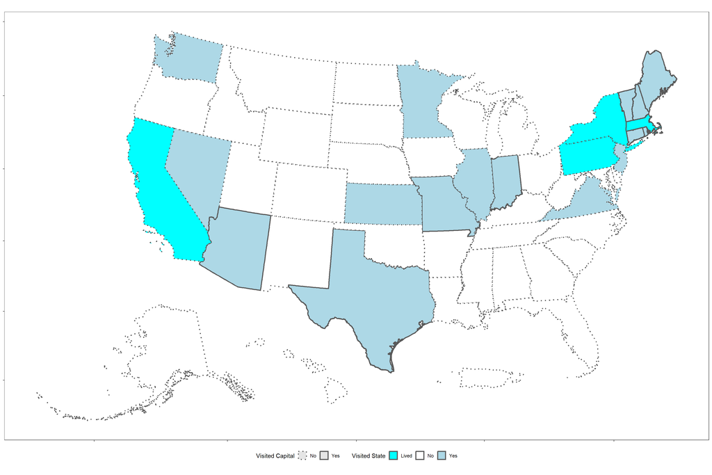

## Step Visualization of first visit (since 2018)

Of course I did not visit these states at the same time, so I wanted to see when I visited each state for the first time. From this point on, I only use data after 2018 since I do not have accurate data prior to this time.

> I still have an issue with xlim here.

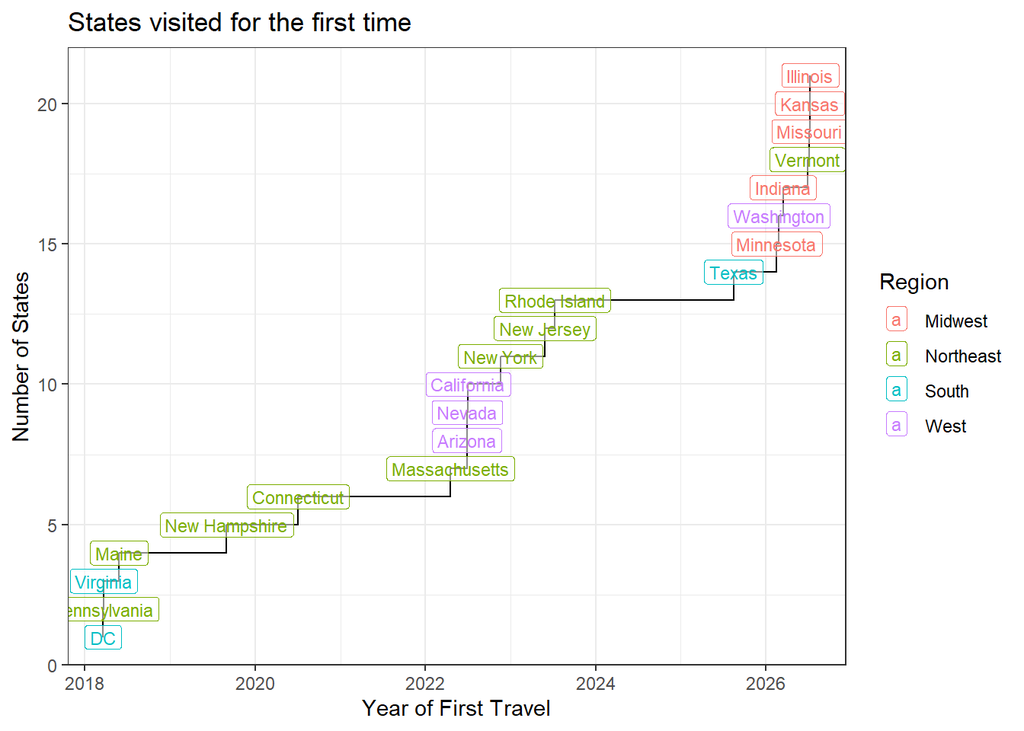

## Visits (days) and living each year (since 2018)

As an exercise in small multiple visualizations, I have here a map from each year highlighting how long I stayed in each state I visited each year (by number of days). I also added a border highlight for any state that I lived in during that time.

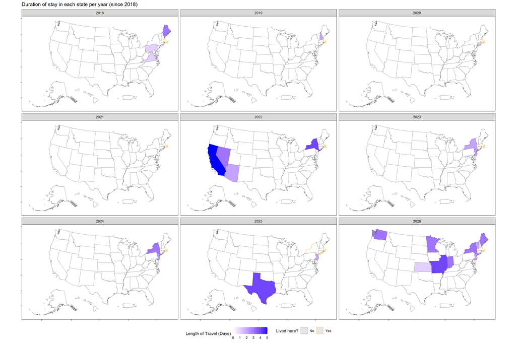

## When did I visit each state? (UNDER CONSTRUCTION)

> Some edits y axis should be colored (using ggtext) the color should indicate business trips or leisure trips

## Wordcloud of Travel Descriptions!

Turns out I am not that creative in my writing. I think I should also include information after the fact.

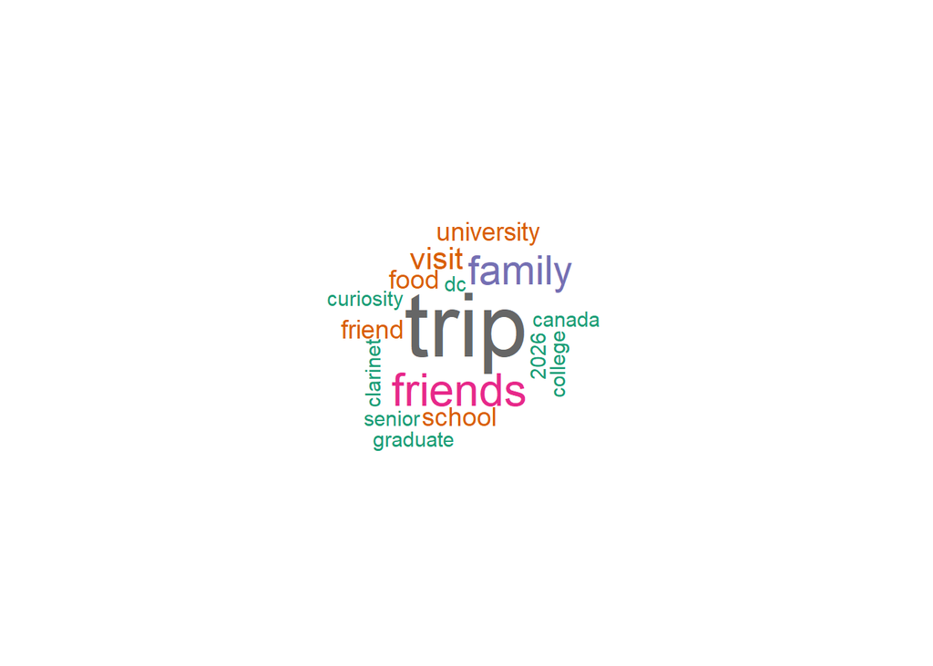

## Travel Map with city directions + indicators of something in particular

> Step 1: Extract all the unique cities I have been to in each travel

*I may want to restructure my data in the future, so this code might break as a result…*

> Step 2: Merge this unique city data with an open-source dataset with geographic location (latitude and longitude)

Currently testing if this works properly with a reduced form of the `unique_cities` dataset

*This dataset doesn’t look at great for my purposes. Doesn’t have a lot of cities I listed…*

```
# A tibble: 49 × 1
   city_abbrev
   <chr>
 1 Washington DC
 2 Philadelphia PA
 3 Arlington VA
 4 Acadia ME
 5 Epsom NH
 6 West Hartford CT
 7 Amherst MA
 8 Phoenix AZ
 9 Reno NV
10 San Diego CA
# ℹ 39 more rows
```

```
# A tibble: 49 × 22
   type     desc              cities start_place start_date end_place end_date
   <chr>    <chr>             <chr>  <chr>       <date>     <chr>     <date>
 1 Leisure  Middle school DC… Washi… Boston, MA  2018-03-19 Boston, … 2018-03-23
 2 Leisure  On our way to DC  Phila… Boston, MA  2018-03-19 Washingt… 2018-03-19
 3 Leisure  Trip to some cav… Arlin… Washington… 2018-03-22 Washingt… 2018-03-22
 4 Leisure  Acadia trip with… Acadia Boston, MA  2018-05-27 Boston, … 2018-05-29
 5 Leisure  Camping trip wit… Epsom  Boston, MA  2019-09-01 Boston, … 2019-09-02
 6 Business Clarinet fix      West … Boston, MA  2020-07-03 Boston, … 2020-07-03
 7 Business Be a Mammoth day… Amher… Boston, MA  2022-04-18 Boston, … 2022-04-18
 8 Unwanted Got stuck in Ari… Phoen… Boston, MA  2022-06-28 Reno, NV  2022-06-29
 9 Business Clarinet Competi… Reno   Phoenix, AZ 2022-06-29 Boston, … 2022-07-01
10 Leisure  California trip … San D… Boston, MA  2022-07-03 Boston, … 2022-07-07
# ℹ 39 more rows
# ℹ 15 more variables: transport_method <chr>, redeye_indicator <chr>,
#   capital_indicator <chr>, region <chr>, travel_length <dbl>,
#   travel_year <dbl>, travel_number_indicator <int>, city_full_name <chr>,
#   visit_order <int>, city_abbrev <chr>, country.etc <chr>, pop <int>,
#   lat <dbl>, long <dbl>, capital <int>
```

> Step 3: `pivot_wider` to create a ton more variables to put all data for a trip into one row > I need to see how to make my plot because this step might be useless other than getting information for the arrows for `start_city` and `end_city` correct

> Step 4: Plot with lines based on geographic location while also coloring in these lines with my `transport_method`

## Distributions (misc… some of these are redundant, most are incomplete…)

Distribution of length of trip by days

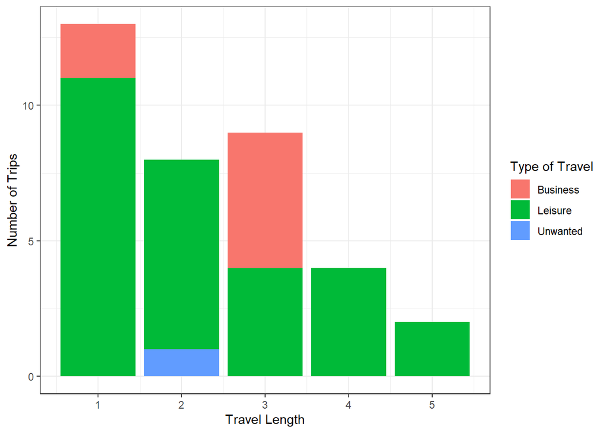

Row chart of type of trip it was (regular, day, redeye). *I think there are some issues here*

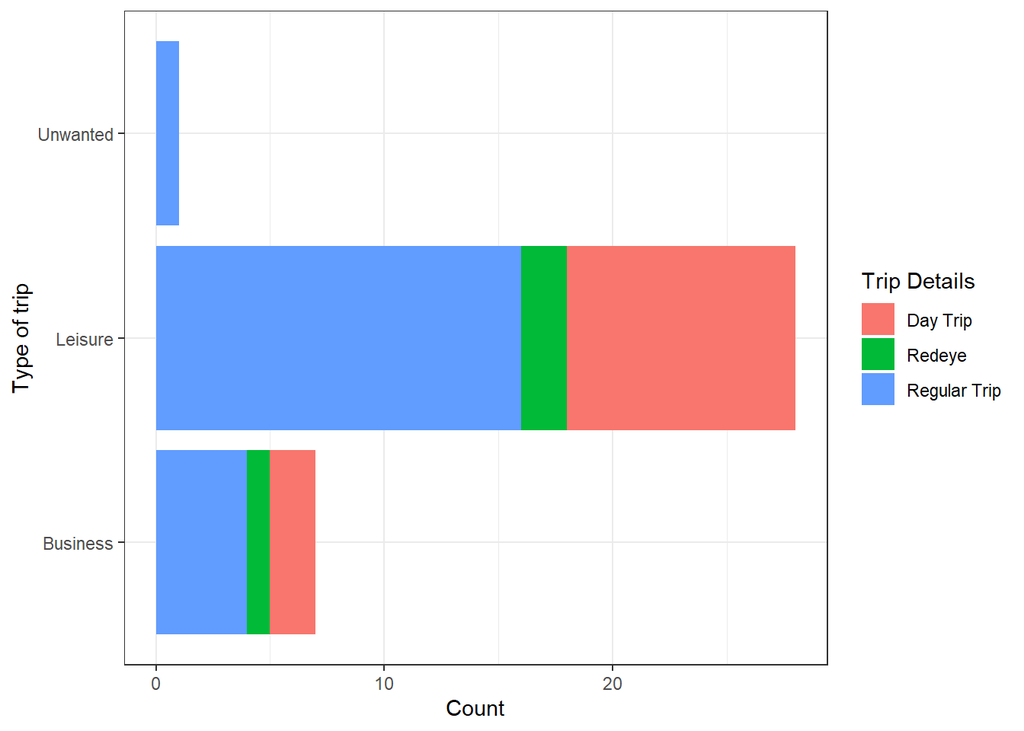

## The following are visuals I am unsure if I should make.

A county map? Includes places I’ve just passed by: something approximate, since the map version here is kind of crazy

> I may just do something from mapchart.net

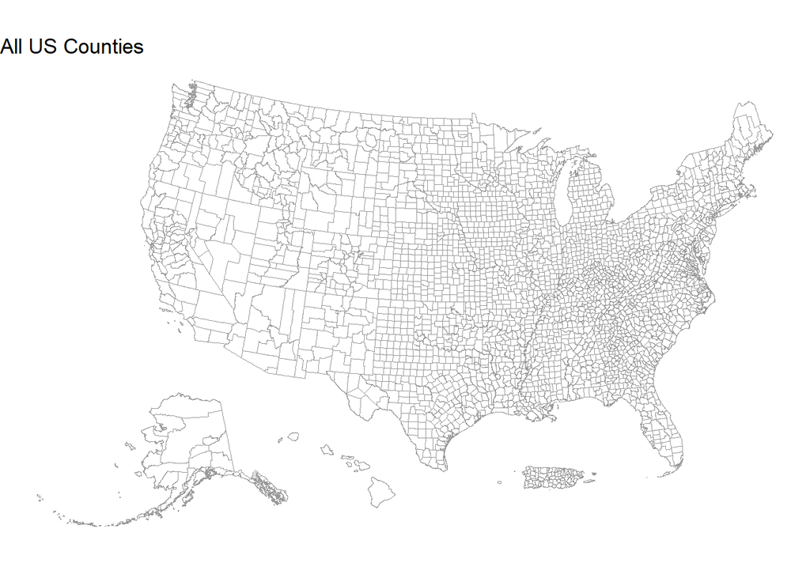